# calcIVT

## calcIVT

### Description

The `calcIVT` package is intended to provide functions useful in calculating Intermediate Value Tables (IVTs) from a dataset.

This package was created in an effort to analyze flight data in order to better identify abnormalities as they arise in the data. Because a typical flight is composed of several very different phases, this package allows allows for the data to be subsetted by discrete phases so that abnormalities can be identified at specific phases of the flight rather than trying to treat the data as a single continuous entity. Data lacking these discrete phases can still be handled using the package by simply setting the discrete phases to 1.

### Getting Started

This guide is structured with the assumption that you are beginning with a basic understanding of R, and aims to provide an understandable blueprint for implementing the `calcIVT` functionality within your own data.

The first thing you will need to do is install the `calcIVT` package. You will need access to the [martingale repository](http://martingale.pnl.gov/computing/repos/) in order to obtain the package. After permissions for access have been granted, the package can then be installed by:

```r
install.packages("calcIVT", repos="http://martingale.pnl.gov/computing/repos")
```

Once the package has been installed, the library can be loaded so that the functions can be used. A complete list of the functions contained within the `calcIVT` package can be seen using:

```r
library(calcIVT)
help(package=calcIVT)
```

### Package Structure

The graphic below provides a heirarchical depiction of how the functions contained within the `calcIVT` package are related.

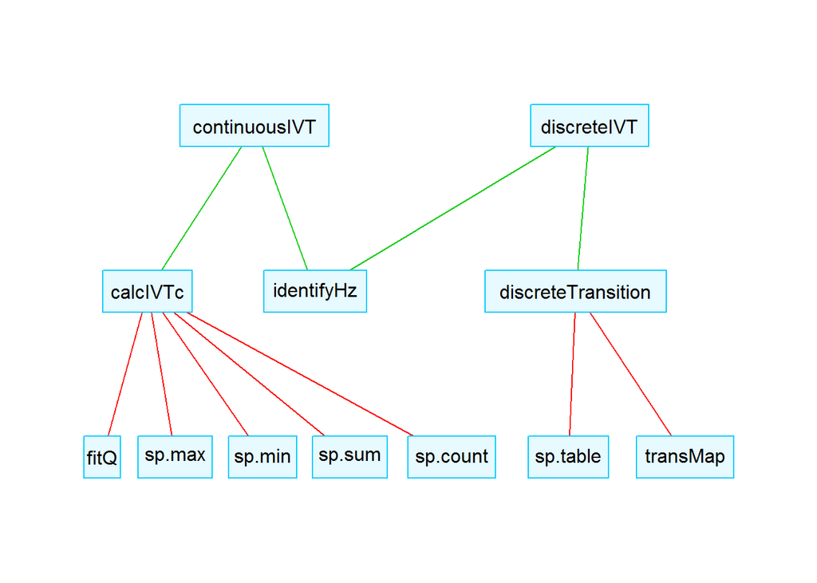

### continuousIVT() Example

The `continuousIVT()` function is intended to calculate IVTs for multiple continuous variables. These IVTs are important because they can be used in conjunction with several analysis methods as a means to identify anomalies within the data. Let’s look at an example.

Suppose you have a set of dataset that contains measurements of the continuous variables speed, altitude, and the tail rudder angle of a particular flight. These measurements are take once per second and associated with the corresponding phase of the flight; in this case the phases are take-off, flight, and landing. We will create our fake dataset as follows:

```r
#Flight Variables#

# vector containing speed at each second of the flight
speed <- c(rnorm(600,60,5),rnorm(6000,300,10),rnorm(1800,60,5))

# vector containing altitutde at each second of the flight
altitude <- c(rep(10,600),rnorm(6000,20000,1000),rep(10,1800))

# vector containing tail rudder angle of the plane at each second of the flight
trAngle <- rnorm(8400,0,20)

# integer vector identifying phase at each second of the flight
#(1 = Take off, 2 = Flight, 3 = Landing)
phase.vec <- c(rep(1,600),rep(2,6000),rep(3,1800))
```

Now we can define some of the function parameters that we will need in order to use the `continuousIVT()` function.

```r
#Function Parameters

# vector with names of flight variables
cNames <- c("speed","altitude","trAngle")

# vector identifying unique phases of the flight
phases.to.process <- c(1,2,3)

# Define number of seconds in the flight
seconds <- 8400
```

Remember that you can see a list of arguments required for the `continuousIVT()` function using:

```r
?continuousIVT
```

It should be noted that there are additional arguments `nominal.skip`, `nominal.bw`, and `actual.min.max` however these arguments have default values so we are going to leave them alone. Additional information on these can be found within the help document.

Now we can use the `continuousIVT()` function to obtain the IVTs for each of the continuous variables.

```r
cResultIVT <-continuousIVT(cNames, phase.vec, phases.to.process, seconds)
cResultIVT
```

```
##                     speed      altitude trAngle
## p.1.a.total         36126         14869     146
## p.1.b.total           120          9928      14
## p.1.c.total            21          1797      -5
## p.1.d.total          3182         22443   11935
## p.1.a.ss          2189623      72289617   38553
## p.1.b.ss             3404      22266116    1861
## p.1.c.ss              117        699414     290
## p.1.d.ss            29952     101449471  250328
## p.1.a.min              45            10     -58
## p.1.b.min              -3             0      -5
## p.1.c.min               0             0      -3
## p.1.d.min               2             0       6
## p.1.a.max              74            10      68
## p.1.b.max              33          2834       9
## p.1.c.max               6           459       2
## p.1.d.max              66          5200      30
## p.1.n.count           600           600     600
## p.1.start.value        58            10       6
## p.1.end.value          65            10       1
## p.2.a.total       1800902     119956541   -2930
## p.2.b.total            -2           150       1
## p.2.c.total           -42         -3535       1
## p.2.d.total         57732       5856699  116514
## p.2.a.ss        540689294 2399677703735  490303
## p.2.b.ss            11879      98166781   20883
## p.2.c.ss              908       8510723    2790
## p.2.d.ss           614436    6250124016 2411027
## p.2.a.min             264         16182     -91
## p.2.b.min             -34         -2739      -6
## p.2.c.min              -6          -525      -2
## p.2.d.min               3           265       6
## p.2.a.max             334         23563      66
## p.2.b.max              32          2784       7
## p.2.c.max               1           148       2
## p.2.d.max              68          5864      42
## p.2.n.count          6000          6000    6000
## p.2.start.value       281         19035      -4
## p.2.end.value         311         21378     -16
## p.3.a.total        108088         28219    -572
## p.3.b.total          -117        -10078      21
## p.3.c.total            21          1738       4
## p.3.d.total          9003         25825   35427
## p.3.a.ss          6511531      88216028  137027
## p.3.b.ss             3605      22318856    6340
## p.3.c.ss              160        694399     850
## p.3.d.ss            63058     134394391  743785
## p.3.a.min              42            10     -78
## p.3.b.min             -33         -2725      -7
## p.3.c.min              -1             0      -2
## p.3.d.min               1             0       5
## p.3.a.max              79            10      75
## p.3.b.max               2             0       8
## p.3.c.max               6           495       3
## p.3.d.max              69          5904      38
## p.3.n.count          1800          1800    1800
## p.3.start.value        65            10      39
## p.3.end.value          63            10       2
```

You may notice that the output shown above is slightly different than your own. I rounded the values and removed the scientific notation to hopefully make the results more readable. If you look at the rownames you can see that they are named systematically and in the following form:

**p.[phase].[coefficient].[intermediate value]**

### discreteIVT() Example

The `discreteIVT()` function is intended to calculate the percentage of time in each state of a discrete variable as well as the number and nature of transitions between states. This information is summarized by phase and can handle multiple discrete variables. Let’s take a look at an example.

We will continue with the flight theme and create a dataset containing a set of discrete variables collected each second for the duration of the flight.

```r
#Flight Variables

# vector containing discrete state of forward thrust (On=1 Off=0)
fwdThrust <- c(rep(0,300),rep(1,6300),rep(0,60),rep(1,1740))

# vector containing discrete state of forward thrust (On=1 Off=0)
rvseThrust <- c(rep(0,6600),rep(1,60),rep(0,1740))

# vector containing discrete state of landing gear (Down=1 Up=0)
lgearDown <- c(rep(1,720),rep(0,5760),rep(1,1920))

# vector containing discrete state of direction (N=1 E=2 S=3 W=4)
direction <- c(rep(1,2000),rep(2,5000),rep(3,1400))

# integer vector identifying phase at each second of the flight
phase.vec <- c(rep(1,600),rep(2,6000),rep(3,1800))
```

Now we can define some of the function parameters that we will need in order to use the `discreteIVT()` function.

```r
#Function Parameters

# vector with names of flight variables
dNames <- c("fwdThrust","rvseThrust","lgearDown","direction")

# vector identifying unique phases of the flight
phases.to.process <- c(1,2,3)

# Define number of seconds in the flight
seconds <- 8400
```

Remember that you can see a list of arguments required for the `discreteIVT()` function using:

```r
?discreteIVT
```

Now that we have our data we can use the `discreteIVT()` function to get a summary of the discrete states and transitions over each phase of the data.

```r
dResult <- discreteIVT(dNames, phase.vec, phases.to.process, seconds)
dResult
```

```
##                               1    2    3
## fwdThrust.percent.00_00     0.5 0.00 0.03
## fwdThrust.percent.01_01     0.5 1.00 0.97
## fwdThrust.transition.00_01  1.0 0.00 1.00
## fwdThrust.transition.01_00  0.0 0.00 1.00
## rvseThrust.percent.00_00    1.0 1.00 0.97
## rvseThrust.percent.01_01    0.0 0.00 0.03
## rvseThrust.transition.00_01 0.0 0.00 1.00
## rvseThrust.transition.01_00 0.0 0.00 1.00
## lgearDown.percent.00_00     0.0 0.96 0.00
## lgearDown.percent.01_01     1.0 0.04 1.00
## lgearDown.transition.00_01  0.0 1.00 0.00
## lgearDown.transition.01_00  0.0 1.00 0.00
## direction.percent.01_01     1.0 0.23 0.00
## direction.percent.02_02     0.0 0.77 0.22
## direction.percent.03_03     0.0 0.00 0.78
## direction.transition.01_02  0.0 1.00 0.00
## direction.transition.01_03  0.0 0.00 0.00
## direction.transition.02_01  0.0 0.00 0.00
## direction.transition.02_03  0.0 0.00 1.00
## direction.transition.03_01  0.0 0.00 0.00
## direction.transition.03_02  0.0 0.00 0.00
```

The output shown will be slightly different than yours because I rounded the values and transposed the matrix in order to facilitate better readability for the sake of this guide. As you can see there is a clear structure in the row names (column names in your case) which is described below:

**[variable].[frequency].[from].[to]**

- **[variable]** Designates the discrete variable of interest from the data
  - fwdThrust
  - rvseThrust
  - lgearDown
  - direction
- **[frequency]** Either a duration or count summarizing discrete states
  - percent - displays the percent of time during a phase the discrete state did not change
  - transition - records a count of each type of unique discrete state transitions as specified by the from and to components for each phase.
- **[from]** Key indicating the discrete state of the variable before
  - XX - Number ranging over all possible discrete states of the variable of interest defined
- **[to]** Key indicating the discrete state of the variable after
  - XX - Number ranging over all possible discrete states of the variable of interest defined